# excel

### Question 1: What is the difference between 'Paste' and 'Paste Special' in Excel? Briefly explain with examples.

**Answer:**

The primary difference between 'Paste' and 'Paste Special' in Excel lies in the level of control they offer over what is being pasted.

**Paste (`Ctrl + V`)**

- **Function:** This is the standard paste command. It copies and pastes *everything* from the source cell(s) to the destination cell(s). This includes the cell's value, formula, formatting (font, color, borders), comments, and data validation.
- **Example:** If you copy cell `A1` which contains the formula `=B1+C1` and has a yellow fill color and bold text, and you 'Paste' it into cell `A2`, cell `A2` will now have the formula `=B2+C2`, the yellow fill, and bold text.

**Paste Special (`Ctrl + Alt + V`)**

- **Function:** This command gives you granular control to paste only specific attributes of the copied cell(s). When you use Paste Special, a dialog box appears with various options.
- **Common Options & Examples:**
  - **Values:** Pastes only the calculated result of a formula, not the formula itself. If `A1` contains `=B1+C1` (which equals 10), pasting as 'Values' will put the number `10` in the destination cell, not the formula.
  - **Formulas:** Pastes only the formulas, without any formatting.
  - **Formats:** Pastes only the cell formatting (like colors, borders, font style), not the content.
  - **Column Widths:** Applies the column width of the source column to the destination column.
  - **Transpose:** Changes the orientation of the copied data. Rows become columns, and columns become rows.
  - **Operations:** Allows you to perform a mathematical operation (Add, Subtract, Multiply, Divide) between the copied cells and the destination cells.

### Question 2: Describe the functions and usefulness of 'Freeze Panes' and 'Split Panes' in Excel.

**Answer:**

Both 'Freeze Panes' and 'Split Panes' are features in Excel designed to make viewing large datasets more manageable by keeping certain parts of the worksheet visible while scrolling through the rest. However, they function differently.

**Freeze Panes**

- **Function:** This feature locks specific rows at the top and/or specific columns on the left of the screen. When you scroll down or across the worksheet, the frozen rows and columns remain in place.
- **Usefulness:** It is incredibly useful for keeping headers visible. When working with a large table, you can freeze the header row so that as you scroll down through hundreds of rows of data, you always know what each column represents. Similarly, you can freeze an ID or Name column to keep it visible while you scroll horizontally through many data columns.
- **How to Use:** Go to the `View` tab > `Freeze Panes`. You have three options:
  1. `Freeze Panes`: Locks rows above and columns to the left of the selected cell.
  2. `Freeze Top Row`: Locks only the first row.
  3. `Freeze First Column`: Locks only the first column.

**Split Panes**

- **Function:** This feature divides the worksheet into two or four separate, scrollable panes (windows). Each pane can be scrolled independently, allowing you to view different parts of the same sheet simultaneously.
- **Usefulness:** 'Split Panes' is useful when you need to compare two sections of a large worksheet that are far apart. For example, you could compare the data in row 10 with the data in row 500 without having to scroll back and forth repeatedly. You can create either a vertical split, a horizontal split, or both.
- **How to Use:** Go to the `View` tab > `Split`. Excel will split the window at the location of your active cell. You can drag the split bars to resize the panes.

### Question 3: Explain the difference between inserting a new row and inserting a new column in Excel. Can you insert multiple rows or columns at once?

**Answer:**

**Difference between Inserting a Row and a Column:**

The fundamental difference lies in the orientation and placement of the new cells.

- **Inserting a New Row:** When you insert a new row, a new horizontal line of cells is added across the entire worksheet. The new row is inserted *above* the currently selected row. For example, if you select row 5 and choose 'Insert', a new blank row will be created at the position of row 5, and the old row 5 (and all subsequent rows) will be pushed down.
- **Inserting a New Column:** When you insert a new column, a new vertical line of cells is added from the top to the bottom of the worksheet. The new column is inserted to the *left* of the currently selected column. For example, if you select column C and choose 'Insert', a new blank column will be created at the position of column C, and the old column C (and all subsequent columns) will be shifted to the right.

**Inserting Multiple Rows or Columns:**

Yes, you can absolutely insert multiple rows or columns at once. The number of rows or columns you select before inserting determines how many will be added.

- **To insert multiple rows:** Select the number of rows you wish to add by clicking and dragging down the row headers (the numbers on the left side of the screen). For instance, if you want to add 3 new rows above the current row 5, you would select rows 5, 6, and 7. Then, right-click on the selection and choose 'Insert'. Three new blank rows will be added.
- **To insert multiple columns:** Similarly, select the number of columns you want to add by clicking and dragging across the column headers (the letters at the top). If you want to add 2 new columns to the left of column C, you would select columns C and D. Then, right-click and choose 'Insert'. Two new blank columns will be added.

### Question 4: What are logical functions in Excel? Provide examples of at least two logical functions and their applications.

**Answer:**

**Logical Functions in Excel**

Logical functions are a core component of Excel's formula capabilities. Their primary purpose is to test whether a certain condition is `TRUE` or `FALSE`. They are the building blocks for decision-making within a spreadsheet. Based on the `TRUE` or `FALSE` result, you can make your spreadsheet perform different actions, making your analysis dynamic and automated.

Here are two examples of essential logical functions:

**1. IF Function**

- **Syntax:** `=IF(logical_test, [value_if_true], [value_if_false])`
- **Description:** The `IF` function checks if a condition is met (`logical_test`). It returns one value if the condition is true and another value if it's false.
- **Application:** As a data analyst, you might use this to categorize data. For example, imagine you have a list of sales figures in column A. You could use the `IF` function to determine if a sales target of $500 was met.
  - **Formula:** `=IF(A2>500, "Met Target", "Below Target")`
  - **Result:** If the value in cell `A2` is 600, this formula will return the text "Met Target". If the value is 450, it will return "Below Target".

**2. AND Function**

- **Syntax:** `=AND(logical1, [logical2], ...)`
- **Description:** The `AND` function checks multiple conditions simultaneously. It returns `TRUE` only if *all* of its arguments evaluate to `TRUE`. If even one argument is `FALSE`, the function returns `FALSE`.
- **Application:** This is often nested inside an `IF` function for more complex criteria. Suppose you want to identify employees eligible for a bonus. The criteria are that they must be in the 'Sales' department (column B) AND have sales (column C) greater than $10,000.
  - **Formula:** `=IF(AND(B2="Sales", C2>10000), "Bonus Eligible", "Not Eligible")`
  - **Result:** This formula will only return "Bonus Eligible" if the employee is in the Sales department *and* their sales exceed $10,000. If either condition is not met, it will return "Not Eligible".

### Question 5: Discuss the purpose of 'XLOOKUP' and how it differs from the traditional 'VLOOKUP' function.

**Answer:**

**Purpose of XLOOKUP**

The `XLOOKUP` function is a modern and powerful function in Excel designed to find and retrieve data from a range or table. It was created to overcome the limitations of older lookup functions like `VLOOKUP` and `HLOOKUP`. Its purpose is to look for a specified value in one column or row (`lookup_array`) and return a corresponding value from another column or row (`return_array`).

**How XLOOKUP Differs from VLOOKUP**

`XLOOKUP` is superior to `VLOOKUP` in several key ways, making it more flexible, intuitive, and less error-prone for data analysts.

1. **Search Direction:**
   - **VLOOKUP:** Can only search for a value in the *leftmost column* of a table array and return a value from a column to its right.
   - **XLOOKUP:** Can search in *any column* and return a value from any other column, regardless of its position (left or right of the lookup column). This eliminates the need to rearrange your data.
2. **Default Match Type:**
   - **VLOOKUP:** Defaults to an *approximate match* if the final argument is omitted. This is a common source of errors for new users who often need an exact match.
   - **XLOOKUP:** Defaults to an *exact match*, which is what is needed in most data analysis scenarios. This makes it safer and more intuitive to use.
3. **Column Insertion/Deletion:**
   - **VLOOKUP:** Relies on a static column index number (e.g., return the value from the 3rd column). If you insert or delete a column within the table array, the formula breaks because the index number is no longer correct.
   - **XLOOKUP:** Uses separate `lookup_array` and `return_array` ranges. This makes the formula resilient to changes in the worksheet structure. If you add or remove columns between the lookup and return arrays, the formula continues to work correctly.
4. **Handling Errors:**
   - **VLOOKUP:** Returns a `#N/A` error if no match is found. To handle this, you have to wrap it in an `IFERROR` function (e.g., `=IFERROR(VLOOKUP(...), "Not Found")`).
   - **XLOOKUP:** Has a built-in `[if_not_found]` argument, making the formula cleaner and easier to write (e.g., `=XLOOKUP(lookup_value, lookup_array, return_array, "Not Found")`).
5. **Search Mode:**
   - **VLOOKUP:** Can only search from top-to-bottom.
   - **XLOOKUP:** Can search from top-to-bottom (default) or bottom-to-top by specifying the optional `[search_mode]` argument. This is useful for finding the last occurrence of a value.

### Question 7: Demonstrate how to insert and delete multiple rows and columns in Excel.

**Answer:**

#### Representation of Screenshot (After Inserting):

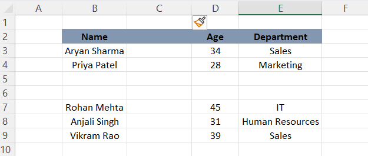

### Question 8: Use Excel's 'Find and Replace' feature to update department names in a sample table.

**Answer:**

Let's say the 'Human Resources' department needs to be renamed to 'HR'.

#### Representation of Screenshot (Before Replace):

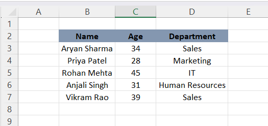

#### Representation of Screenshot (After Replace):

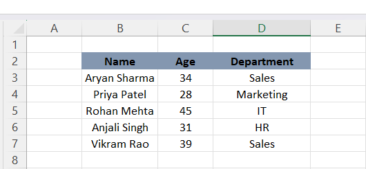

**Answer:**

I've created a small dataset of 'Monthly Sales' to perform the calculations.

**Formulas Used:**

- In cell `C8`, for Average: `=AVERAGE(C3:C7)`
- In cell `C9`, for Maximum: `=MAX(C3:C7)`
- In cell `C10`, for Minimum: `=MIN(C3:C7)`

#### Representation of Screenshot (Formulas and Results):

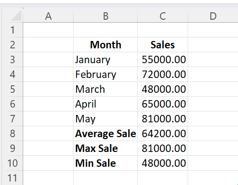

### Question 10: You're working with a dataset that contains missing values. As a Data Scientist, explain how you'd detect and handle missing data using Excel. Mention tools like: Go To Special, ISBLANK, COUNTBLANK.

**Answer:**

As a data analyst, handling missing data is a critical step in the data cleaning process to ensure the accuracy and reliability of any subsequent analysis. In Excel, we can use several tools to detect and manage these missing values.

#### **1. Detecting Missing Data**

First, we need to find out where and how many missing values exist.

- **COUNTBLANK Function:** This function is used to get a quick count of empty cells in a range. This is useful for summarizing the extent of the missing data.
  - *Syntax:* `=COUNTBLANK(range)`
  - *Example:* `=COUNTBLANK(A2:C10)` would return the total number of empty cells in that range.
- **Go To Special:** This is a powerful tool for visually identifying and selecting all blank cells at once.
  - *Steps:*
    1. Select the entire data range.
    2. Press `F5` or `Ctrl + G` to open the 'Go To' dialog box.
    3. Click the 'Special...' button.
    4. Select the 'Blanks' option and click OK.
  - *Result:* All empty cells within the selected range will be highlighted. At this point, you can immediately take action, such as filling them with a specific color to keep them visible or typing a value (e.g., 0) and pressing `Ctrl + Enter` to fill all selected blank cells at once.
- **Filtering:** You can apply a filter to your data (`Data` tab > `Filter`) and then use the dropdown arrow on a column header to filter for and display only the rows with '(Blanks)'.

#### **2. Handling Missing Data**

Once detected, there are several common strategies for handling missing values:

- **Deletion:** If a row has many missing values, or if the missing value is in a critical column, you might choose to delete the entire row. This is generally done only if the dataset is large and the number of rows to be deleted is small.
- **Imputation (Filling the Blanks):** This is the most common method. You replace the missing values with a substitute value.
  - **For Numerical Data:** You can fill blanks with the mean (average), median, or mode of the column. This is often a better approach than using zero, which can skew calculations.
  - **For Categorical Data:** You can fill blanks with the most frequent category (mode) or a new category like "Unknown" or "Not Applicable".
- **Using Formulas (ISBLANK):** The `ISBLANK` function can be used within other functions (like `IF`) to handle missing data dynamically. `ISBLANK` checks if a cell is empty and returns `TRUE` or `FALSE`.
  - *Syntax:* `ISBLANK(cell)`
  - *Example:* Imagine you have a 'Commission' column (C) that is calculated from a 'Sales' column (B), but some sales data is missing. You could use the formula: `=IF(ISBLANK(B2), "Data Missing", B2*0.10)`. This formula checks if the sales cell is empty. If it is, it outputs "Data Missing"; otherwise, it calculates the commission.

#### Representation of Screenshot (Using 'Go To Special' to Identify Blanks):

The screenshot below represents a dataset after using the 'Go To Special' > 'Blanks' feature. The blank cells in the 'Age' and 'Department' columns have been automatically selected and are highlighted in grey, making them easy to see and process.

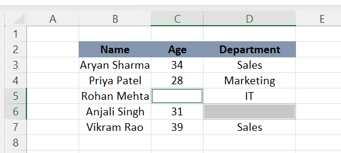